```python
from fastai2.test import *
from fastai2.basics import *
from fastai2.callback.all import *
from fastai2.vision.all import *
```

## Single-label classification

### Gathering the data

We use the data block API to get our data in a `DataBunch`. Here our inputs are images and our targets categories. The images are all in a folder, so we use `get_image_files` to collect them all, a `RandomSplitter` to split between training and validation, then we get the label from the filenames with a regex labeller.

```python
pets = DataBlock(blocks=(ImageBlock, CategoryBlock),
                 get_items=get_image_files,
                 splitter=RandomSplitter(),
                 get_y=RegexLabeller(pat = r'/([^/]+)_\d+.jpg$'))
```

```python
dbunch = pets.databunch(untar_data(URLs.PETS)/"images", item_tfms=RandomResizedCrop(460, min_scale=0.75), bs=32,
                        batch_tfms=[*aug_transforms(size=299, max_warp=0), Normalize(*imagenet_stats)])
```

Then we can look at some of our pictures with `dbunch.show_batch()`

```python
len(dbunch.train_ds.items)
```

```
5912
```

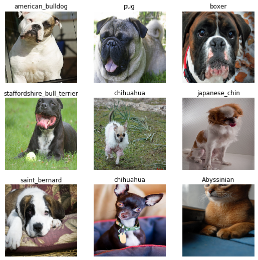

```python
dbunch.show_batch(max_n=9)
```

### Using a pretrained model

First let's import a `resnet34` form torchvision.

```python
from torchvision.models import resnet34,resnet50
```

```python
#from fastai2.vision.models.xresnet import xresnet50
```

We will use the AdamW optimizer (Adam with true weight decay).

```python
opt_func = partial(Adam, lr=slice(3e-3), wd=0.01, eps=1e-8)
```

```python
#Or use Ranger
#def opt_func(p, lr=slice(3e-3)): return Lookahead(RAdam(p, lr=lr, mom=0.95, wd=0.01))
```

Then we can call `cnn_learner` to build a `Learner` from our `DataBunch`. Since we are using a pretrained model, it comes automatically frozen, which means only the head is going to be trained.

```python
learn = cnn_learner(dbunch, resnet50, opt_func=opt_func, metrics=error_rate, config=cnn_config(ps=0.33)).to_fp16()
```

We can train the head a little bit using the 1cycle policy.

```python
learn.fit_one_cycle(1)
```

| epoch | train_loss | valid_loss | error_rate | time |
| --- | --- | --- | --- | --- |
| 0 | 0.455705 | 0.239800 | 0.077808 | 00:36 |

```python
#learn.fit_one_cycle(8, slice(3e-3))
```

Then we can unfreeze the model and use discriminative learning rates.

```python
learn.unfreeze()
# learn.fit_one_cycle(4, slice(1e-5, 1e-3))
learn.fit_one_cycle(1, slice(1e-5, 1e-3))
```

[output not shown]

### Seeing results

```python
learn.predict(dbunch.train_ds.items[0])
```

```
('miniature_pinscher',
 tensor(26),
 tensor([1.3895e-03, 1.1339e-04, 4.7167e-06, 1.8621e-04, 3.6235e-06, 2.1440e-05,
         1.2743e-07, 8.3745e-07, 1.4442e-06, 8.6767e-05, 5.1617e-04, 4.7932e-03,
         2.0890e-06, 3.9454e-05, 1.0844e-05, 1.0174e-04, 3.2597e-05, 4.6821e-03,
         5.1652e-06, 2.3441e-06, 8.5756e-05, 5.3335e-07, 1.6687e-06, 5.7565e-06,
         1.2709e-05, 5.5136e-07, 9.8764e-01, 9.1082e-07, 1.4529e-05, 6.8028e-06,
         1.8983e-06, 4.2363e-06, 4.4036e-05, 5.3980e-05, 3.2933e-05, 1.0753e-06,
         1.0164e-04]))
```

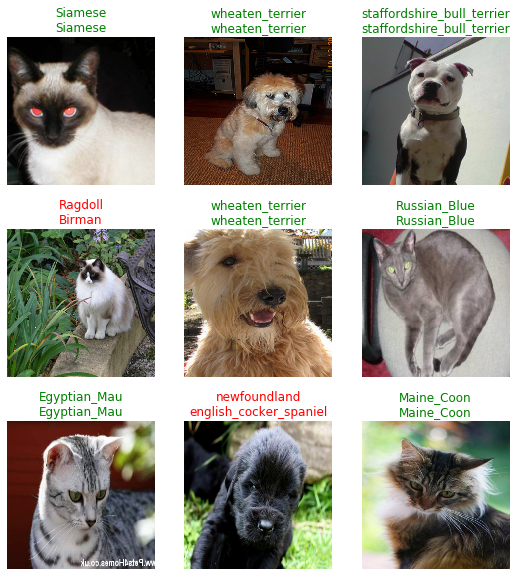

```python
learn.show_results(max_n=9)
```

```python
interp = Interpretation.from_learner(learn)
```

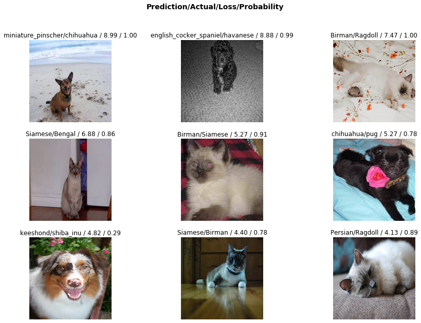

```python
interp.plot_top_losses(9, figsize=(15,10))
```

## Multi-label classification

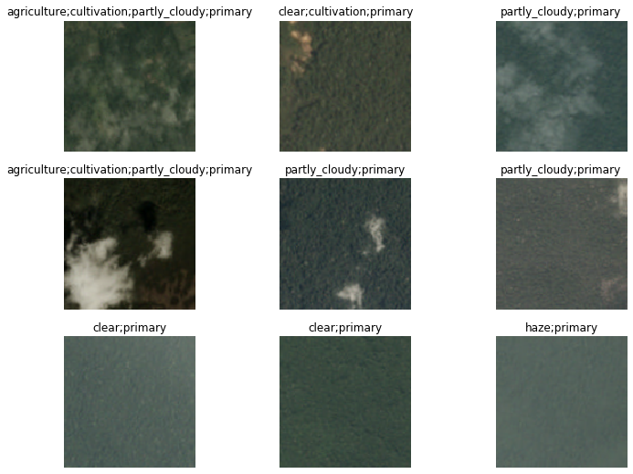

```python
planet_source = untar_data(URLs.PLANET_TINY)
df = pd.read_csv(planet_source/"labels.csv")

planet = DataBlock(blocks=(ImageBlock, MultiCategoryBlock),
                   get_x=lambda x:planet_source/"train"/f'{x[0]}.jpg',
                   splitter=RandomSplitter(),
                   get_y=lambda x:x[1].split(' '))

dbunch = planet.databunch(df.values,
         batch_tfms=aug_transforms(flip_vert=True, max_lighting=0.1, max_zoom=1.05, max_warp=0.))
dbunch.show_batch(max_n=9, figsize=(12,9))
```

```python
learn = cnn_learner(dbunch, resnet34, opt_func=opt_func, metrics=accuracy_multi)
learn.fit_one_cycle(1)
```

| epoch | train_loss | valid_loss | accuracy_multi | time |
| --- | --- | --- | --- | --- |
| 0 | 0.984292 | 0.989365 | 0.417857 | 00:04 |

Since we have a weird first transform (that is there to preprocess the names in the dataframe and make proper filenames) we remove it when we want to do inference in `Learner.predict` or `test_dl` with the `rm_type_tfms` arg.

```python
learn.predict(planet_source/f'train/train_10030.jpg', rm_type_tfms=1)
```

```
((#5) [agriculture,artisinal_mine,cultivation,habitation,haze],
 tensor([ True,  True, False, False, False, False,  True,  True,  True, False,
         False, False, False, False]),
 tensor([0.6245, 0.8218, 0.3397, 0.3111, 0.2421, 0.3718, 0.6801, 0.8657, 0.6233,
         0.4426, 0.2959, 0.3173, 0.2264, 0.2996]))
```

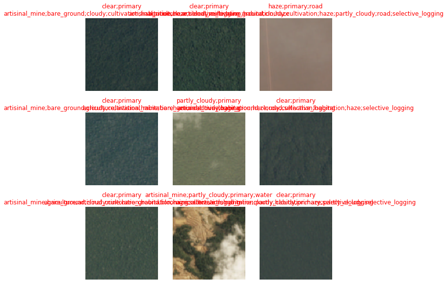

```python
learn.show_results(max_n=9)
```

```python
interp = Interpretation.from_learner(learn)
```

|  | target | predicted | probabilities | loss |
| --- | --- | --- | --- | --- |
| 0 | clear;primary;water | agriculture;artisinal_mine;bare_ground;cloudy;cultivation;habitation;haze;partly_cloudy;road;selective_logging | tensor([0.9854, 0.9713, 0.6691, 0.3597, 0.0635, 0.6860, 0.9405, 0.7924, 0.9206,\n 0.9019, 0.2825, 0.5693, 0.8724, 0.1841]) | 2.0251517295837402 |
| 1 | clear;primary;water | agriculture;artisinal_mine;bare_ground;cloudy;cultivation;haze;partly_cloudy;primary;selective_logging;water | tensor([0.8294, 0.9305, 0.6096, 0.4756, 0.0079, 0.8483, 0.8683, 0.1757, 0.9623,\n 0.8643, 0.7121, 0.4005, 0.6676, 0.6034]) | 1.621275544166565 |
| 2 | agriculture;clear;primary;road;water | agriculture;artisinal_mine;bare_ground;blooming;cloudy;cultivation;habitation;haze;partly_cloudy;road;selective_logging | tensor([0.9785, 0.9503, 0.5710, 0.5760, 0.1992, 0.7882, 0.9902, 0.9602, 0.7873,\n 0.8915, 0.4699, 0.9225, 0.6990, 0.3487]) | 1.6141308546066284 |
| 3 | artisinal_mine;clear;primary;road;water | agriculture;artisinal_mine;cultivation;habitation;haze;partly_cloudy;primary;road;selective_logging;water | tensor([0.9320, 0.9605, 0.2803, 0.1407, 0.3144, 0.1803, 0.9808, 0.9928, 0.9133,\n 0.8834, 0.5903, 0.5928, 0.8103, 0.7938]) | 1.4995286464691162 |
| 4 | artisinal_mine;clear;primary;water | agriculture;artisinal_mine;blooming;cultivation;habitation;haze;partly_cloudy;primary;road | tensor([0.9789, 0.8111, 0.4456, 0.7128, 0.3238, 0.0783, 0.5463, 0.9456, 0.7621,\n 0.9920, 0.9421, 0.8675, 0.1426, 0.2553]) | 1.4772450923919678 |
| 5 | agriculture;clear;primary;road | agriculture;artisinal_mine;bare_ground;cloudy;cultivation;habitation;haze;partly_cloudy;primary | tensor([0.7373, 0.8035, 0.6012, 0.3029, 0.0942, 0.7587, 0.8844, 0.7664, 0.8060,\n 0.7086, 0.5070, 0.2195, 0.2832, 0.2694]) | 1.165945053100586 |
| 6 | agriculture;clear;primary;road | agriculture;artisinal_mine;bare_ground;habitation;haze;partly_cloudy;road;selective_logging;water | tensor([0.9951, 0.8910, 0.5872, 0.4731, 0.1032, 0.2087, 0.4710, 0.8880, 0.5711,\n 0.8639, 0.1938, 0.8785, 0.6007, 0.7388]) | 1.139198660850525 |
| 7 | agriculture;partly_cloudy;primary | agriculture;artisinal_mine;bare_ground;cloudy;cultivation;habitation;haze;road;selective_logging | tensor([0.8243, 0.8928, 0.8016, 0.2904, 0.1221, 0.7102, 0.8035, 0.7743, 0.6381,\n 0.3634, 0.0965, 0.5089, 0.5524, 0.3672]) | 1.0865401029586792 |
| 8 | clear;primary | agriculture;artisinal_mine;bare_ground;cloudy;cultivation;habitation;haze;partly_cloudy;selective_logging | tensor([0.5802, 0.8437, 0.6628, 0.2134, 0.2427, 0.6364, 0.5345, 0.7982, 0.6738,\n 0.5906, 0.2330, 0.2999, 0.8398, 0.3854]) | 1.0705785751342773 |

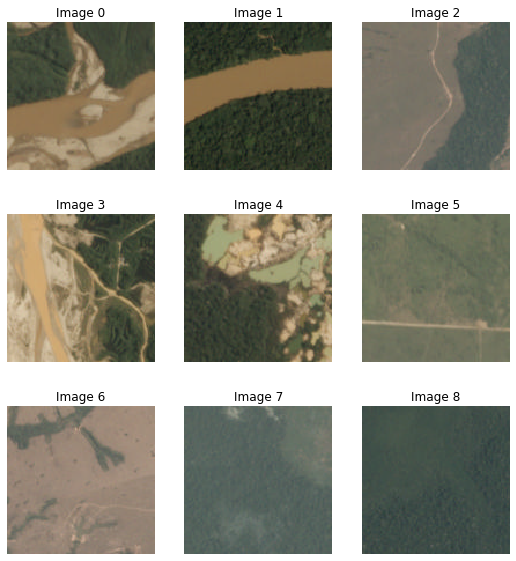

```python
interp.plot_top_losses(9)
```

## Segmentation

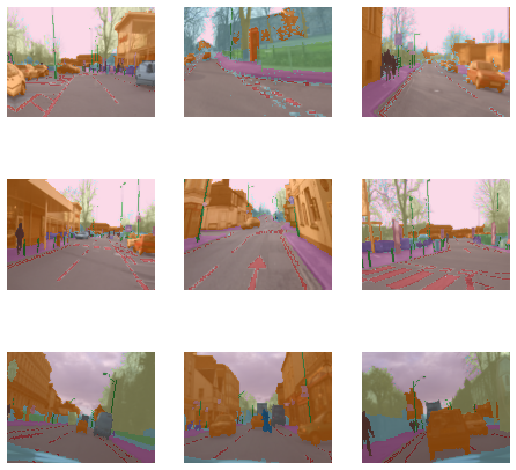

```python
camvid = DataBlock(blocks=(ImageBlock, ImageBlock(cls=PILMask)),
                   get_items=get_image_files,
                   splitter=RandomSplitter(),
                   get_y=lambda o: untar_data(URLs.CAMVID_TINY)/'labels'/f'{o.stem}_P{o.suffix}')

dbunch = camvid.databunch(untar_data(URLs.CAMVID_TINY)/"images", batch_tfms=aug_transforms())
dbunch.show_batch(max_n=9, vmin=1, vmax=30)
```

```python
#TODO: Find a way to pass the classes properly
dbunch.vocab = np.loadtxt(untar_data(URLs.CAMVID_TINY)/'codes.txt', dtype=str)
```

```python
learn = unet_learner(dbunch, resnet34, opt_func=opt_func, config=unet_config())
learn.fit_one_cycle(1, 1e-3)
# Use the below to get somewhat reasonable results - but takes a bit longer
# learn.fit_one_cycle(8, 3e-3)
```

| epoch | train_loss | valid_loss | time |
| --- | --- | --- | --- |
| 0 | 3.413007 | 4.757127 | 00:05 |

```python
learn.predict(dbunch.train_ds.items[0]);
```

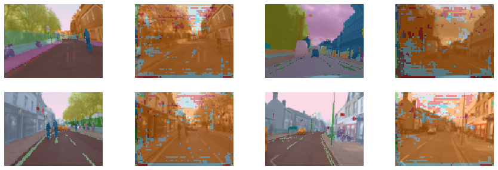

```python
learn.show_results(max_n=4, figsize=(15,5))
```

## Points

```python
path = untar_data(URLs.BIWI_SAMPLE)
fn2ctr = (path/'centers.pkl').load()
```

```python
biwi = DataBlock(blocks=(ImageBlock, PointBlock),
                 get_items = get_image_files,
                 get_y = lambda o:fn2ctr[o.name].flip(0),
                 splitter=RandomSplitter())
```

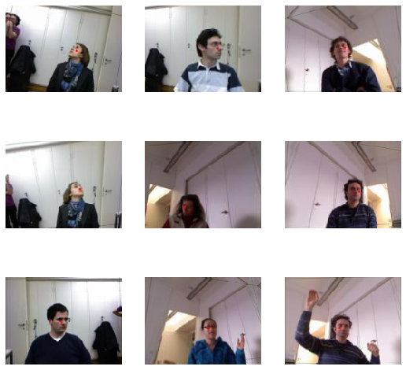

```python
dbunch = biwi.databunch(path, batch_tfms=[*aug_transforms(size=(120,160)), Normalize(*imagenet_stats)])
dbunch.show_batch(max_n=9, vmin=1, vmax=30)
```

```python
#TODO: look for attrs in after_item
dbunch.c = dbunch.after_item.c
dbunch.train_ds.loss_func = MSELossFlat()
```

```python
learn = cnn_learner(dbunch, resnet34, opt_func=opt_func)
learn.fit_one_cycle(3, 1e-3)
```

| epoch | train_loss | valid_loss | time |
| --- | --- | --- | --- |
| 0 | 3.999626 | 1.520517 | 00:03 |
| 1 | 3.387719 | 1.699020 | 00:03 |
| 2 | 3.338441 | 1.403246 | 00:03 |

```python
learn.predict(dbunch.train_ds.items[0])
```

```
(tensor([56.6983, -2.8033]),
 tensor([-0.2913, -1.0467]),
 tensor([-0.2913, -1.0467]))
```

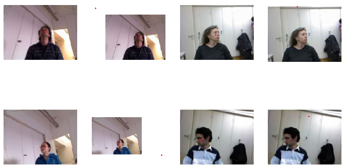

```python
learn.show_results(max_n=4)
```